# Excess rentals in TfL bike sharing

2017-10-31T22:26:09-05:00

# Challenge 1: Excess rentals in TfL bike sharing

Recall the TfL data on how many bikes were hired every single day. We can get the latest data by running the following codes:

```r
url <- "https://data.london.gov.uk/download/number-bicycle-hires/ac29363e-e0cb-47cc-a97a-e216d900a6b0/tfl-daily-cycle-hires.xlsx"

# Download TFL data to temporary file
httr::GET(url, write_disk(bike.temp <- tempfile(fileext = ".xlsx")))
```

```
## Response [https://airdrive-secure.s3-eu-west-1.amazonaws.com/london/dataset/number-bicycle-hires/2021-09-23T12%3A52%3A20/tfl-daily-cycle-hires.xlsx?X-Amz-Algorithm=AWS4-HMAC-SHA256&X-Amz-Credential=AKIAJJDIMAIVZJDICKHA%2F20211018%2Feu-west-1%2Fs3%2Faws4_request&X-Amz-Date=20211018T185949Z&X-Amz-E…
##   Date: 2021-10-18 19:03
##   Status: 200
##   Content-Type: application/vnd.openxmlformats-officedocument.spreadsheetml.sheet
##   Size: 174 kB
## <ON DISK>  /var/folders/gj/s535nsqs26q4fv0w46rnj5gm0000gn/T//RtmpeBgNtC/filec7a540806fa3.xlsx
```

```r
# Use read_excel to read it as dataframe
bike0 <- read_excel(bike.temp,
                   sheet = "Data",
                   range = cell_cols("A:B"))

# change dates to get year, month, and week
bike <- bike0 %>%
  clean_names() %>%
  rename (bikes_hired = number_of_bicycle_hires) %>%
  mutate (year = year(day),
          month = lubridate::month(day, label = TRUE),
          week = isoweek(day))
```

We first calculate the mean of monthly number of bicycles hired between 2016 and 2019, and then get the monthly changes in TFL bike rentals using excess_rental method. We set “up” for the positive excess rental (when monthly actual_rentals is greater than expected_rentals), and “down” for the negative excess rental (when monthly actual_rentals is less than expected_rentals).

```r
bike_month_16_19 <- bike %>%
  filter(year>=2016&year<=2019)%>%
  group_by(month) %>%
  summarise(expected_rental=mean(bikes_hired))


bike_month <- bike %>%
  filter(year>=2016) %>%
  group_by(year,month) %>%
  summarise(bike_hired_month=mean(bikes_hired),.groups = 'drop')

bike_month_comp <- merge(bike_month,bike_month_16_19,by="month") %>%
  mutate(excess_rentals = bike_hired_month - expected_rental,
         up = ifelse(bike_hired_month>expected_rental, excess_rentals, 0), #up gives the diffrence between actual and expected rentals when actual>expected
         down = ifelse(bike_hired_month<expected_rental, excess_rentals, 0)) #down gives the diffrence between actual and expected rentals when actual<expected
```

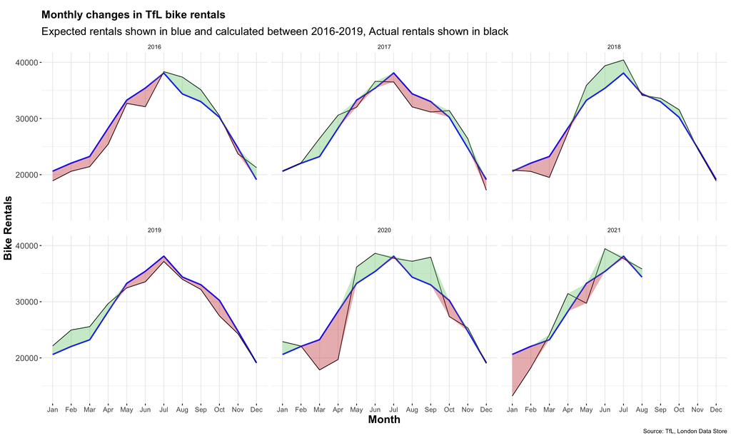

```r
ggplot(bike_month_comp,aes(month))+
  geom_line(aes(x=month,y=expected_rental,colour="Expected",group=year),size=1)+
  geom_line(aes(x=month,y=bike_hired_month,colour="Actual",group=year))+
  geom_ribbon(aes(ymin=expected_rental,
                  ymax=expected_rental+up,group=year),alpha=0.4,fill="#7DCD85")+ #plot the areas in green using up when actual>expected
  geom_ribbon(aes(ymin=expected_rental+down,
                  ymax=expected_rental,group=year),alpha=0.4,fill="#CB454A")+ #plot the areas in red when using down actual>expected
  scale_colour_manual("",breaks=c("Expected","Actual"),values=c("blue","black"))+
  facet_wrap(~year)+
  theme_minimal()  +
  theme(legend.position = "none",
        plot.title =element_text(size=16, face='bold',hjust = 0,margin = margin(10,0,10,0)),
        plot.subtitle =element_text(size=16, hjust = 0), #put titles in the middle
        axis.text.x = element_text(size=10),
        axis.text.y = element_text(size=12),
        axis.ticks.x = element_line(),
        axis.ticks.y=element_line(),
        axis.title.x = element_text(size=16,face='bold'),
        axis.title.y = element_text(size=16,face='bold'),
        ) +
  labs(title = "Monthly changes in TfL bike rentals",
       subtitle = "Expected rentals shown in blue and calculated between 2016-2019, Actual rentals shown in black",
       caption= "Source: TfL, London Data Store",
       x="Month", y="Bike Rentals")
```

We then calculate the mean of weekly number of bicycles hired, and the weekly percentage change between actual and expected bike rentals between 2016 and 2019. We set “up” for the positive percentage change (when weekly actual_rentals is greater than expected_rentals), and “down” for the negative percentage change (when weekly actual_rentals is less than expected_rentals).

```r
glimpse(bike)
```

```
## Rows: 4,051
## Columns: 5
## $ day         <dttm> 2010-07-30, 2010-07-31, 2010-08-01, 2010-08-02, 2010-08-0…
## $ bikes_hired <dbl> 6897, 5564, 4303, 6642, 7966, 7893, 8724, 9797, 6631, 7864…
## $ year        <dbl> 2010, 2010, 2010, 2010, 2010, 2010, 2010, 2010, 2010, 2010…
## $ month       <ord> Jul, Jul, Aug, Aug, Aug, Aug, Aug, Aug, Aug, Aug, Aug, Aug…
## $ week        <dbl> 30, 30, 30, 31, 31, 31, 31, 31, 31, 31, 32, 32, 32, 32, 32…
```

```r
bike_week_16_19 <- bike %>%
  filter(year>=2016&year<=2019)%>%
  group_by(week) %>%
  summarise(expected_rental=mean(bikes_hired))


bike_week <- bike %>%
  filter(year>=2016) %>%
  filter(!(year==2021&week==53))%>%
  group_by(year,week) %>%
  summarise(bike_hired_week=mean(bikes_hired),.groups = 'drop')

bike_week_comp <- merge(bike_week,bike_week_16_19,by="week") %>%
  mutate(percentage_rentals_change = (bike_hired_week - expected_rental)/expected_rental,
         up = ifelse(bike_hired_week>expected_rental, percentage_rentals_change, 0), #up gives the percentage diffrence between actual and expected rentals when actual>expected
         down = ifelse(bike_hired_week<expected_rental, percentage_rentals_change, 0)) #down gives the percentage diffrence between actual and expected rentals when actual<expected
```

The two grey shaded rectangles correspond to Q2 (weeks 14-26) and Q4 (weeks 40-52) are also added.

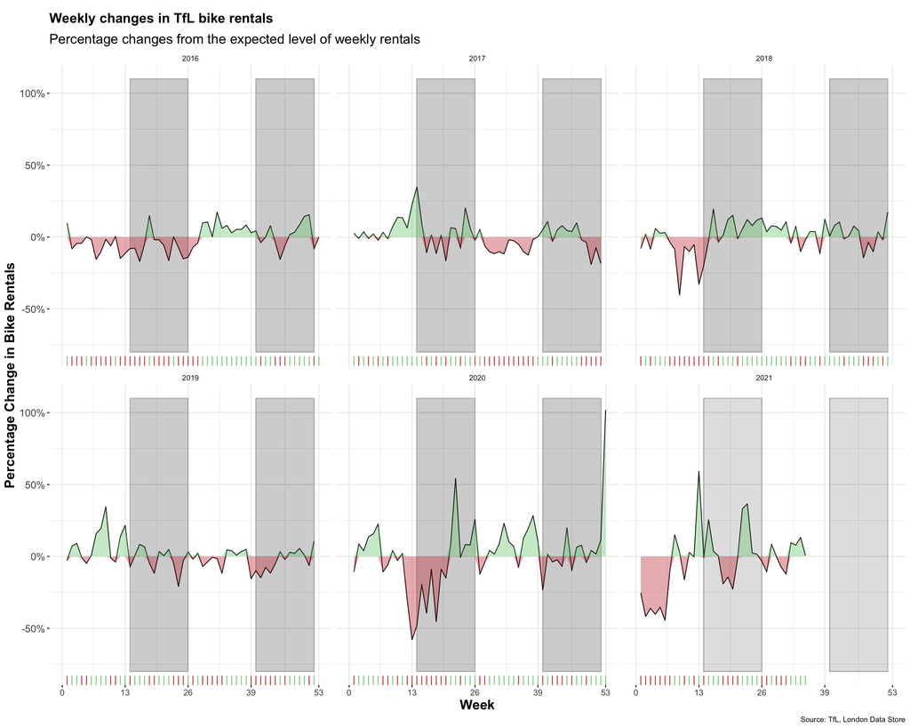

```r
ggplot(bike_week_comp,aes(week))+
  geom_rect(aes(xmin=14,xmax=26,ymin=-0.8,ymax=1.1,group=year),colour="grey",alpha=0.002)+ #plot rectangles for Q2
  geom_rect(aes(xmin=40,xmax=52,ymin=-0.8,ymax=1.1,group=year),colour="grey",alpha=0.002)+ #plot rectangles for Q4
  geom_rug(aes(colour=ifelse(bike_hired_week>=expected_rental,">=0","<0")),sides="b")+ #plot rug for x asis
  scale_colour_manual(values=c("#CB454A","#7DCD85"),name="Actual vs Expected ", guide=FALSE)+
  geom_line(aes(x=week,y=percentage_rentals_change,group=year),colour="black",size=0.5)+
  geom_ribbon(aes(ymin=0,
                  ymax=up,group=year),alpha=0.4,fill="#7DCD85")+ #plot the areas in green using up when actual>expected
  geom_ribbon(aes(ymin=down,
                  ymax=0,group=year),alpha=0.4,fill="#CB454A")+ #plot the areas in red using up when actual>expected
  facet_wrap(~year)+
  theme_minimal()  +
  theme(legend.position = "none",
        plot.title =element_text(size=16, face='bold',hjust = 0,margin = margin(10,0,10,0)),
        plot.subtitle =element_text(size=16, hjust = 0), #put titles in the middle
        axis.text.x = element_text(size=10),
        axis.text.y = element_text(size=12),
        axis.ticks.x = element_line(),
        axis.ticks.y=element_line(),
        axis.title.x = element_text(size=16,face='bold'),
        axis.title.y = element_text(size=16,face='bold'),
        ) +
  labs(title = "Weekly changes in TfL bike rentals",
       subtitle = "Percentage changes from the expected level of weekly rentals", caption= "Source: TfL, London Data Store",
       x="Week", y="Percentage Change in Bike Rentals") +
  scale_x_continuous(breaks=c(0,13,26,39,53),limits=c(0,53))+
  scale_y_continuous(labels=scales::percent)
```